# Questionnaire Data Analysis

# 4. Examination of the Full Dataset

## 4.1 Summary of the Dataset

The following table shows the summary statistics for the pre-results in the control group. The time variables are divided by 60 so that the time is in minutes.

```r
summary_c_pre <-
  df_questionnaire_data[df_questionnaire_data$treatment == "control"
                                       & df_questionnaire_data$time == "pre", ]

summary_c_pre$mctq_SDweek <- as.numeric(summary_c_pre$mctq_SDweek)
summary_c_pre$mctq_SLossWeek <- as.numeric(summary_c_pre$mctq_SLossWeek )
summary_c_pre$mctq_SJL <- as.numeric(summary_c_pre$mctq_SJL)

summary_table <- data.frame(
  mean = apply(summary_c_pre[, c(1:8)], 2, mean, na.rm = T),
  SD = apply(summary_c_pre[, c(1:8)], 2, sd, na.rm = T)
)

summary_table[6, 1] <- summary_table[6, 1] / 60
summary_table[6, 2] <- summary_table[6, 2] / 60
summary_table[7, 1] <- summary_table[7, 1] / 60
summary_table[7, 2] <- summary_table[7, 2] / 60
summary_table[8, 1] <- summary_table[8, 1] / 60
summary_table[8, 2] <- summary_table[8, 2] / 60

summary_table
```

```
##                      mean         SD
## ISI_total       16.120000   3.689173
## PHQ_total       10.666667   3.610171
## GAD_total        8.571429   4.707137
## WSAS_total      17.761905   8.117295
## MHQol_total     20.761905   2.343177
## mctq_SDweek    418.392857 119.813381
## mctq_SLossWeek 120.952381 147.080229
## mctq_SJL        63.229167  39.047624
```

The following table shows the summary statistics for the post-results in the control group.

```r
summary_c_post <-
  df_questionnaire_data[df_questionnaire_data$treatment == "control"
                                       & df_questionnaire_data$time == "post", ]

summary_c_post$mctq_SDweek <- as.numeric(summary_c_post$mctq_SDweek)
summary_c_post$mctq_SLossWeek <- as.numeric(summary_c_post$mctq_SLossWeek )
summary_c_post$mctq_SJL <- as.numeric(summary_c_post$mctq_SJL)

summary_table <- data.frame(
  mean = apply(summary_c_post[, c(1:8)], 2, mean, na.rm = T),
  SD = apply(summary_c_post[, c(1:8)], 2, sd, na.rm = T)
)

summary_table[6, 1] <- summary_table[6, 1] / 60
summary_table[6, 2] <- summary_table[6, 2] / 60
summary_table[7, 1] <- summary_table[7, 1] / 60
summary_table[7, 2] <- summary_table[7, 2] / 60
summary_table[8, 1] <- summary_table[8, 1] / 60
summary_table[8, 2] <- summary_table[8, 2] / 60

summary_table
```

```
##                      mean         SD
## ISI_total       14.120000   3.689173
## PHQ_total        9.666667   3.610171
## GAD_total        7.666667   4.531372
## WSAS_total      15.761905   8.117295
## MHQol_total     18.761905   2.343177
## mctq_SDweek    443.078036 126.882370
## mctq_SLossWeek 114.904762 139.726218
## mctq_SJL        66.959688  41.351434
```

The following table shows the summary statistics for the pre-results in the treatment group.

```r
summary_t_pre <-
  df_questionnaire_data[df_questionnaire_data$treatment == "dCBT-I"
                                       & df_questionnaire_data$time == "pre", ]
summary_t_pre$mctq_SDweek <- as.numeric(summary_t_pre$mctq_SDweek)
summary_t_pre$mctq_SLossWeek <- as.numeric(summary_t_pre$mctq_SLossWeek )
summary_t_pre$mctq_SJL <- as.numeric(summary_t_pre$mctq_SJL)

summary_pret <- data.frame(
  mean = apply(summary_t_pre[, c(1:8)], 2, mean, na.rm = T),
  SD = apply(summary_t_pre[, c(1:8)], 2, sd, na.rm = T)
)

summary_pret[6, 1] <- summary_pret[6, 1] / 60
summary_pret[6, 2] <- summary_pret[6, 2] / 60
summary_pret[7, 1] <- summary_pret[7, 1] / 60
summary_pret[7, 2] <- summary_pret[7, 2] / 60
summary_pret[8, 1] <- summary_pret[8, 1] / 60
summary_pret[8, 2] <- summary_pret[8, 2] / 60

summary_pret
```

```
##                      mean         SD
## ISI_total       16.120000   3.689173
## PHQ_total       10.666667   3.610171
## GAD_total        8.571429   4.707137
## WSAS_total      17.761905   8.117295
## MHQol_total     20.761905   2.343177
## mctq_SDweek    418.392857 119.813381
## mctq_SLossWeek 120.952381 147.080229
## mctq_SJL        63.229167  39.047624
```

The following table shows the summary statistics for the post-results in the treatment group.

```r
summary_t_post <-
  df_questionnaire_data[df_questionnaire_data$treatment == "dCBT-I"
                                       & df_questionnaire_data$time == "post", ]

summary_t_post$mctq_SDweek <- as.numeric(summary_t_post$mctq_SDweek)
summary_t_post$mctq_SLossWeek <- as.numeric(summary_t_post$mctq_SLossWeek )
summary_t_post$mctq_SJL <- as.numeric(summary_t_post$mctq_SJL)

summary_table <- data.frame(
  mean = apply(summary_t_post[, c(1:8)], 2, mean, na.rm = T),
  SD = apply(summary_t_post[, c(1:8)], 2, sd, na.rm = T)
)

summary_table[6, 1] <- summary_table[6, 1] / 60
summary_table[6, 2] <- summary_table[6, 2] / 60
summary_table[7, 1] <- summary_table[7, 1] / 60
summary_table[7, 2] <- summary_table[7, 2] / 60
summary_table[8, 1] <- summary_table[8, 1] / 60
summary_table[8, 2] <- summary_table[8, 2] / 60

summary_table
```

```
##                      mean         SD
## ISI_total        8.680000   3.749667
## PHQ_total        4.857143   3.086838
## GAD_total        4.666667   4.270051
## WSAS_total       9.666667   8.211780
## MHQol_total     19.238095   2.022493
## mctq_SDweek    422.355087 124.388905
## mctq_SLossWeek  31.511255  45.854463
## mctq_SJL       103.509420  93.063388
```

## 4.2 The Ranges of the Outcome Variables

Next, we want to check that all the outcoem variables are within the allowed ranges (the ranges vary per questionnaire).

```r
# Checking that min and max score for each outcome variable aren't out
# of range

## ISI
paste("ISI range is 0-28. Our ISI-score min:",
      min(df_questionnaire_data$ISI_total), "and max:",
      max(df_questionnaire_data$ISI_total))
```

```
## [1] "ISI range is 0-28. Our ISI-score min: 3 and max: 22"
```

```r
## PHQ
paste("PHQ range is 0-27. Our PHQ-score min:",
      min(df_questionnaire_data$PHQ_total, na.rm = T),
      "and max:", max(df_questionnaire_data$PHQ_total, na.rm = T))
```

```
## [1] "PHQ range is 0-27. Our PHQ-score min: 0 and max: 17"
```

```r
## GAD
paste("GAD range is 0-21. Our GAD-score min:",
      min(df_questionnaire_data$GAD_total, na.rm = T),
      "and max:", max(df_questionnaire_data$GAD_total, na.rm = T))
```

```
## [1] "GAD range is 0-21. Our GAD-score min: 0 and max: 18"
```

```r
## WSAS
paste("WSAS range is 0-40. Our WSAS-score min:",
      min(df_questionnaire_data$WSAS_total, na.rm = T),
      "and max:", max(df_questionnaire_data$WSAS_total, na.rm = T))
```

```
## [1] "WSAS range is 0-40. Our WSAS-score min: 0 and max: 38"
```

```r
## MHQol
paste("MHQol range is 0-38. Our MHQol-score min:",
      min(df_questionnaire_data$MHQol_total, na.rm = T),
      "and max:", max(df_questionnaire_data$MHQol_total, na.rm = T))
```

```
## [1] "MHQol range is 0-38. Our MHQol-score min: 14 and max: 25"
```

```r
## MCTQ-SDweek
paste("MCTQ-SDweek (time in seconds) >= 0. Our MCTQ-SDweek -score min:",
      min(df_questionnaire_data$mctq_SDweek, na.rm = T))
```

```
## [1] "MCTQ-SDweek (time in seconds) >= 0. Our MCTQ-SDweek -score min: 6054"
```

```r
## MCTQ-SLossWeek
paste("MCTQ-SLossWeek (time in seconds) >= 0. Our MCTQ-SLossWeek -score min:",
      min(df_questionnaire_data$mctq_SLossWeek, na.rm = T))
```

```
## [1] "MCTQ-SLossWeek (time in seconds) >= 0. Our MCTQ-SLossWeek -score min: 0"
```

```r
## MCTQ-SJL
paste("MCTQ-SJL (time in seconds) >= 0. Our MCTQ-SJL -score min:",
      min(df_questionnaire_data$mctq_SJL, na.rm = T))
```

```
## [1] "MCTQ-SJL (time in seconds) >= 0. Our MCTQ-SJL -score min: 0"
```

## 4.3 Comparing Simulated vs. Actual Data Plots

Next the distribution of the pre-treatment and (simulated) post-treatment were studied and also the distributions for the pre-and pots-results were examined for each variable separately.

### 4.3.1 ISI-Score Distributions

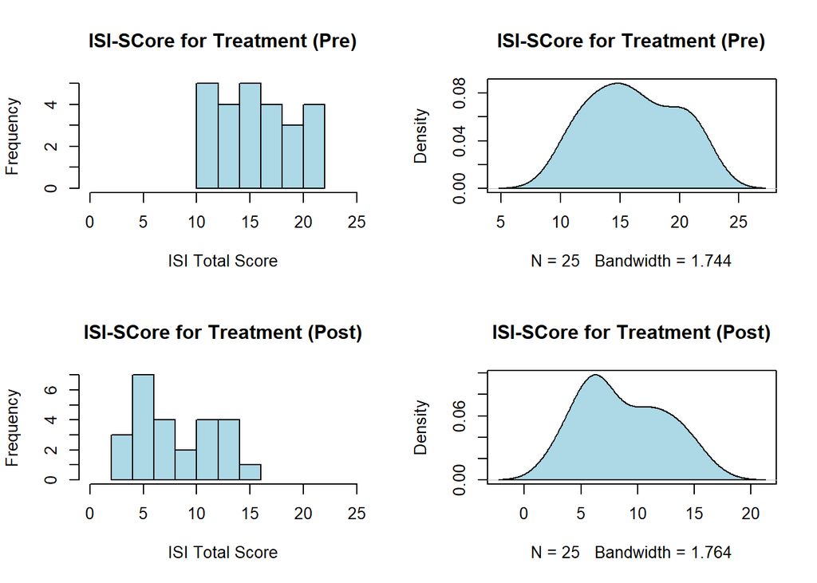

```r
data <- df_questionnaire_data
par(mfrow=c(2,2))

### ISI-SCORE ###

# Treatment Group (Pre)
hist(data[data$treatment == "dCBT-I" & data$time == "pre", 1],
     xlim  = c(0,25),
     main = "ISI-SCore for Treatment (Pre)",
     xlab = "ISI Total Score",
     col = "lightblue")

plot(density(data[data$treatment == "dCBT-I" & data$time == "pre", 1]),
      main = "ISI-SCore for Treatment (Pre)")
polygon(density(data[data$treatment == "dCBT-I" & data$time == "pre", 1]),
        col = "lightblue")


# Treatment Group (Post)
hist(data[data$treatment == "dCBT-I" & data$time == "post", 1],
     xlim  = c(0,25),
     main = "ISI-SCore for Treatment (Post)",
     xlab = "ISI Total Score",
     col = "lightblue")

plot(density(data[data$treatment == "dCBT-I" & data$time == "post", 1]),
      main = "ISI-SCore for Treatment (Post)")
polygon(density(data[data$treatment == "dCBT-I" & data$time == "post", 1]),
        col = "lightblue")
```

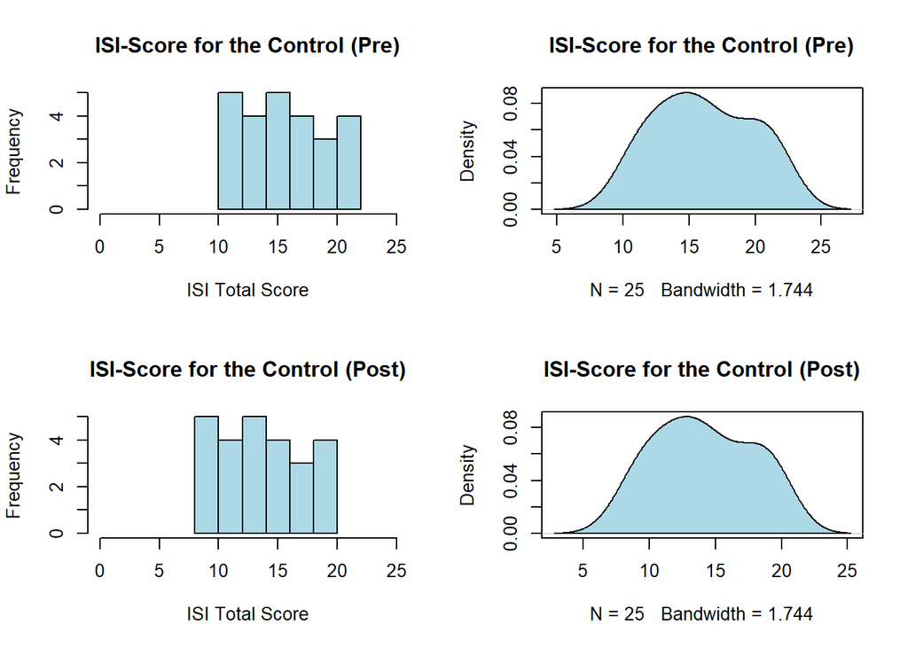

```r
# Control Group (Pre)
hist(data[data$treatment == "control" & data$time == "pre", 1],
     xlim  = c(0,25),
     main = "ISI-Score for the Control (Pre)",
     xlab = "ISI Total Score",
     col = "lightblue")

plot(density(data[data$treatment == "control" & data$time == "pre", 1]),
     main = "ISI-Score for the Control (Pre)")
polygon(density(data[data$treatment == "control" & data$time == "pre", 1]),
        col = "lightblue")


# Control Group (Post)
hist(data[data$treatment == "control" & data$time == "post", 1],
     xlim  = c(0,25),
     main = "ISI-Score for the Control (Post)",
     xlab = "ISI Total Score",
     col = "lightblue")
plot(density(data[data$treatment == "control" & data$time == "post", 1]),
     main = "ISI-Score for the Control (Post)")
polygon(density(data[data$treatment == "control" & data$time == "post", 1]),
        col = "lightblue")
```

### 4.3.2 PHQ-Score Distributions

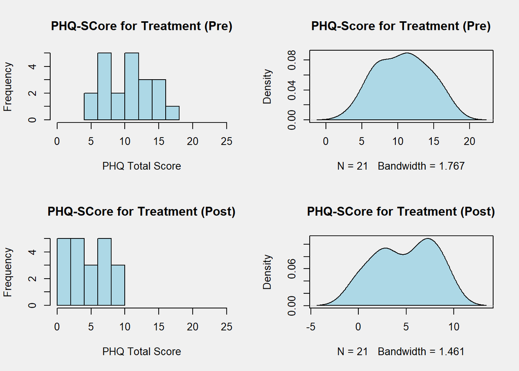

```r
###  PHQ-SCORE ###
par(mfrow=c(2,2), bg = "#f0f0f0")

# Treatment Group (Pre)
hist(data[data$treatment == "dCBT-I" & data$time == "pre", 2],
     xlim  = c(0,25),
     main = "PHQ-SCore for Treatment (Pre)",
     xlab = "PHQ Total Score",
     col = "lightblue")

plot(density(data[data$treatment == "dCBT-I" & data$time == "pre", 2],
             na.rm = T),
     main = "PHQ-Score for Treatment (Pre)")
polygon(density(data[data$treatment == "dCBT-I" & data$time == "pre", 2],
                na.rm = T),
        col = "lightblue")


# Treatment Group (Post)
hist(data[data$treatment == "dCBT-I" & data$time == "post", 2],
     xlim  = c(0,25),
     main = "PHQ-SCore for Treatment (Post)",
     xlab = "PHQ Total Score",
     col = "lightblue")

plot(density(data[data$treatment == "dCBT-I" & data$time == "post", 2],
             na.rm = T),
     main = "PHQ-SCore for Treatment (Post)")
polygon(density(data[data$treatment == "dCBT-I" & data$time == "post", 2],
                na.rm = T),
        col = "lightblue")
```

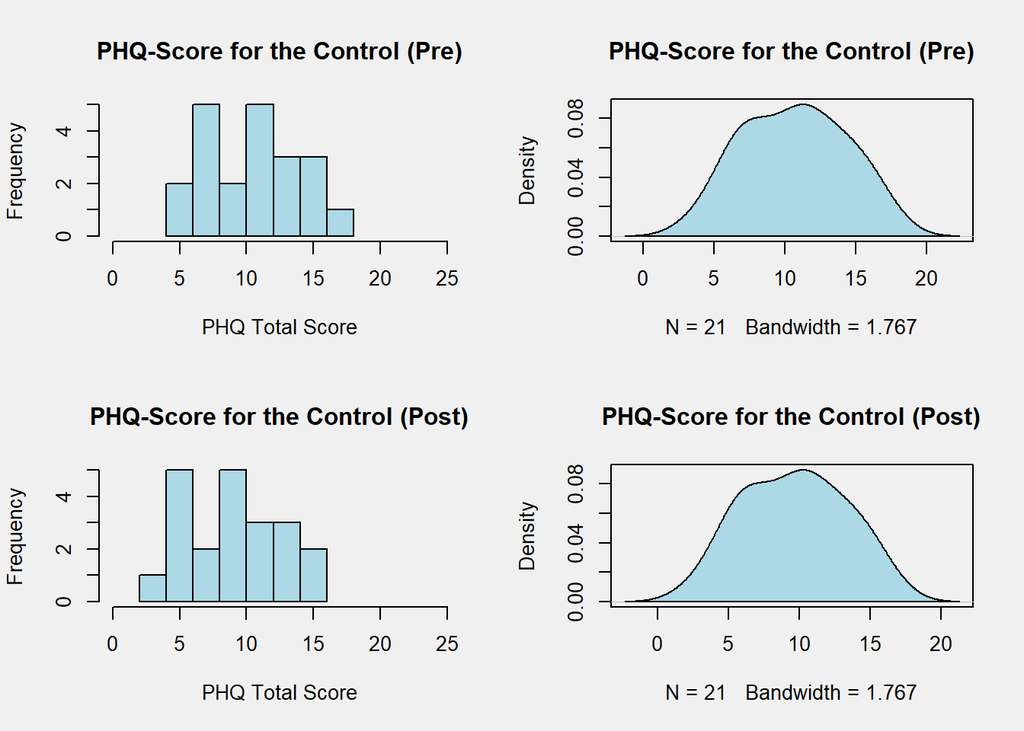

```r
# Control Group (Pre)
hist(data[data$treatment == "control" & data$time == "pre", 2],
     xlim  = c(0,25),
     main = "PHQ-Score for the Control (Pre)",
     xlab = "PHQ Total Score",
     col = "lightblue")

plot(density(data[data$treatment == "control" & data$time == "pre", 2],
             na.rm = T),
      main = "PHQ-Score for the Control (Pre)")
polygon(density(data[data$treatment == "control" & data$time == "pre", 2],
                na.rm = T),
        col = "lightblue")


# Control Group (Post)
hist(data[data$treatment == "control" & data$time == "post", 2],
     xlim  = c(0,25),
     main = "PHQ-Score for the Control (Post)",
     xlab = "PHQ Total Score",
     col = "lightblue")

plot(density(data[data$treatment == "control" & data$time == "post", 2],
             na.rm = T),
      main = "PHQ-Score for the Control (Post)")
polygon(density(data[data$treatment == "control" & data$time == "post", 2],
                na.rm = T),
        col = "lightblue")
```

### 4.3.3 GAD-Score Distributions

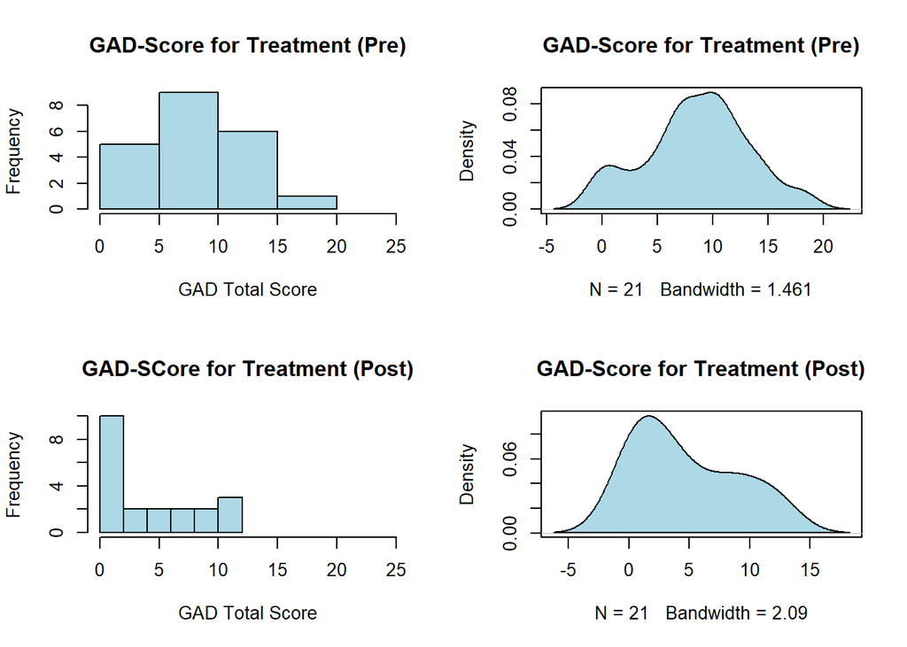

```r
###  GAD-SCORE ###
par(mfrow=c(2,2))

# Treatment Group (Pre)
hist(data[data$treatment == "dCBT-I" & data$time == "pre", 3],
     xlim  = c(0,25),
     main = "GAD-Score for Treatment (Pre)",
     xlab = "GAD Total Score",
     col = "lightblue")

plot(density(data[data$treatment == "dCBT-I" & data$time == "pre", 3],
             na.rm = T),
     main = "GAD-Score for Treatment (Pre)")
polygon(density(data[data$treatment == "dCBT-I" & data$time == "pre", 3],
                na.rm = T),
        col = "lightblue")


# Treatment Group (Post)
hist(data[data$treatment == "dCBT-I" & data$time == "post", 3],
     xlim  = c(0,25),
     main = "GAD-SCore for Treatment (Post)",
     xlab = "GAD Total Score",
     col = "lightblue")

plot(density(data[data$treatment == "dCBT-I" & data$time == "post", 3],
             na.rm = T),
      "GAD-Score for Treatment (Post)")
polygon(density(data[data$treatment == "dCBT-I" & data$time == "post", 3],
                na.rm = T),
        col = "lightblue")
```

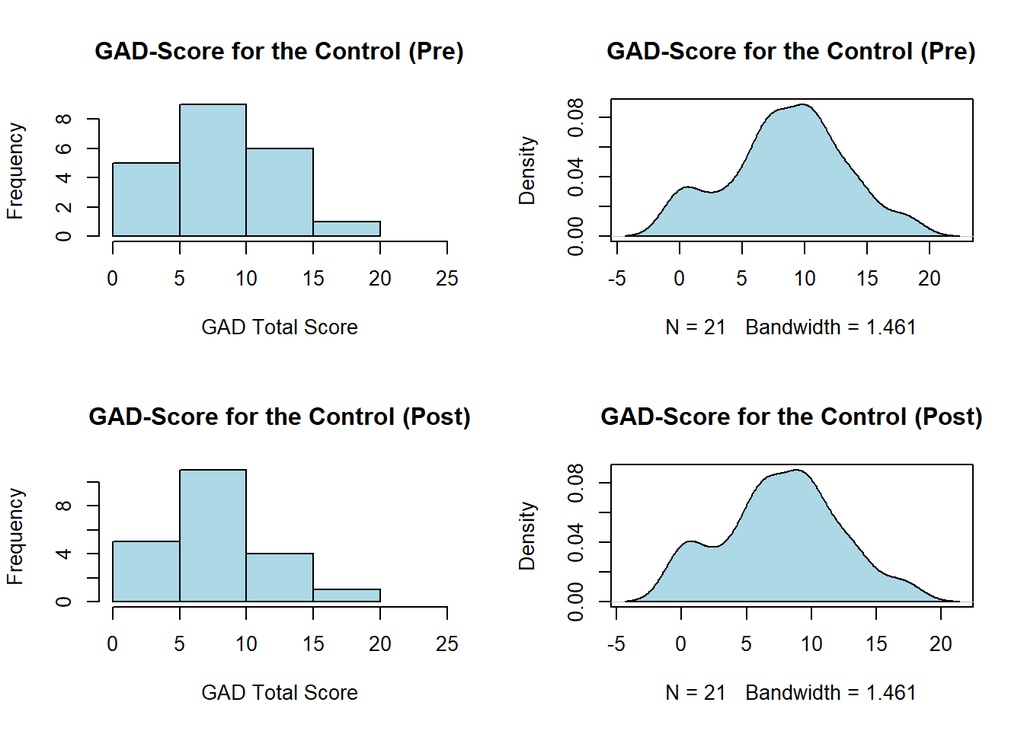

```r
# Control Group (Pre)
hist(data[data$treatment == "control" & data$time == "pre", 3], xlim  = c(0,25),
     main = "GAD-Score for the Control (Pre)",
     xlab = "GAD Total Score",
     col = "lightblue")

plot(density(data[data$treatment == "control" & data$time == "pre", 3],
             na.rm = T),
      main = "GAD-Score for the Control (Pre)")
polygon(density(data[data$treatment == "control" & data$time == "pre", 3],
                na.rm = T),
        col = "lightblue")

# Control Group (Post)
hist(data[data$treatment == "control" & data$time == "post", 3], xlim  = c(0,25),
     main = "GAD-Score for the Control (Post)",
     xlab = "GAD Total Score",
     col = "lightblue")

plot(density(data[data$treatment == "control" & data$time == "post", 3],
             na.rm = T),
      main = "GAD-Score for the Control (Post)")
polygon(density(data[data$treatment == "control" & data$time == "post", 3],
                na.rm = T),
        col = "lightblue")
```

### 4.3.4 WSAS-Score Distributions

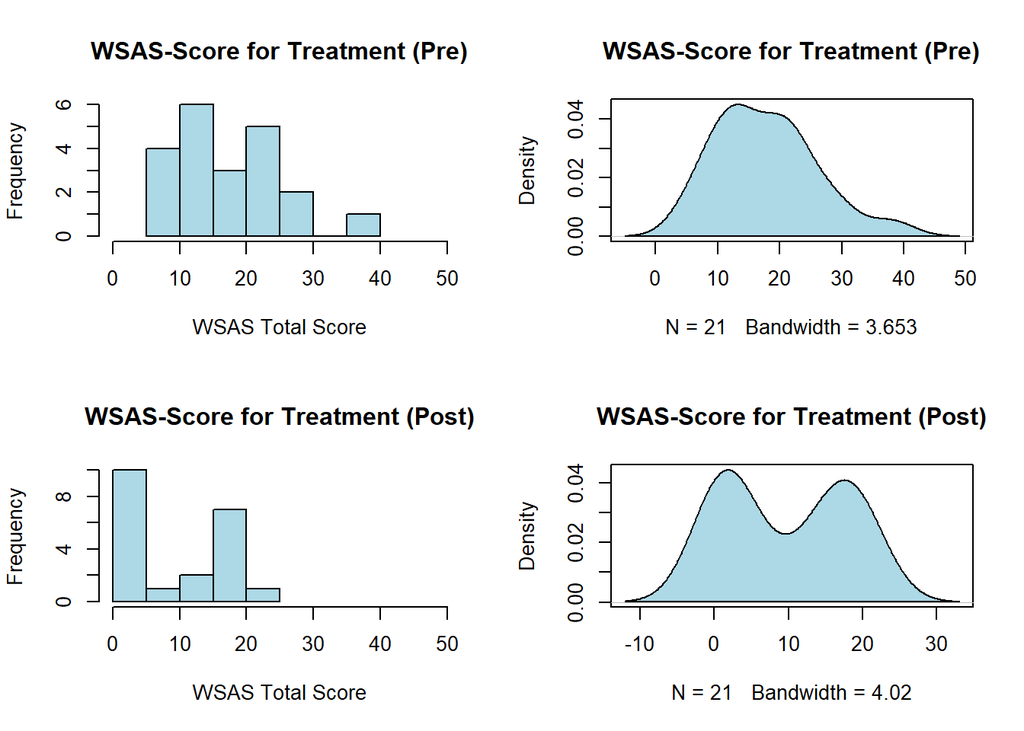

```r
###  WSAS- SCORE ###
par(mfrow=c(2,2))

# Treatment Group (Pre)
hist(data[data$treatment == "dCBT-I" & data$time == "pre", 4],
     xlim  = c(0,50),
     main = "WSAS-Score for Treatment (Pre)",
     xlab = "WSAS Total Score",
     col = "lightblue")

plot(density(data[data$treatment == "dCBT-I" & data$time == "pre", 4],
             na.rm = T),
      main = "WSAS-Score for Treatment (Pre)")
polygon(density(data[data$treatment == "dCBT-I" & data$time == "pre", 4],
                na.rm = T),
        col = "lightblue")


# Treatment Group (Post)
hist(data[data$treatment == "dCBT-I" & data$time == "post", 4],
     xlim  = c(0,50),
     main = "WSAS-Score for Treatment (Post)",
     xlab = "WSAS Total Score",
     col = "lightblue")

plot(density(data[data$treatment == "dCBT-I" & data$time == "post", 4],
             na.rm = T),
      main = "WSAS-Score for Treatment (Post)")
polygon(density(data[data$treatment == "dCBT-I" & data$time == "post", 4],
                na.rm = T),
        col = "lightblue")
```

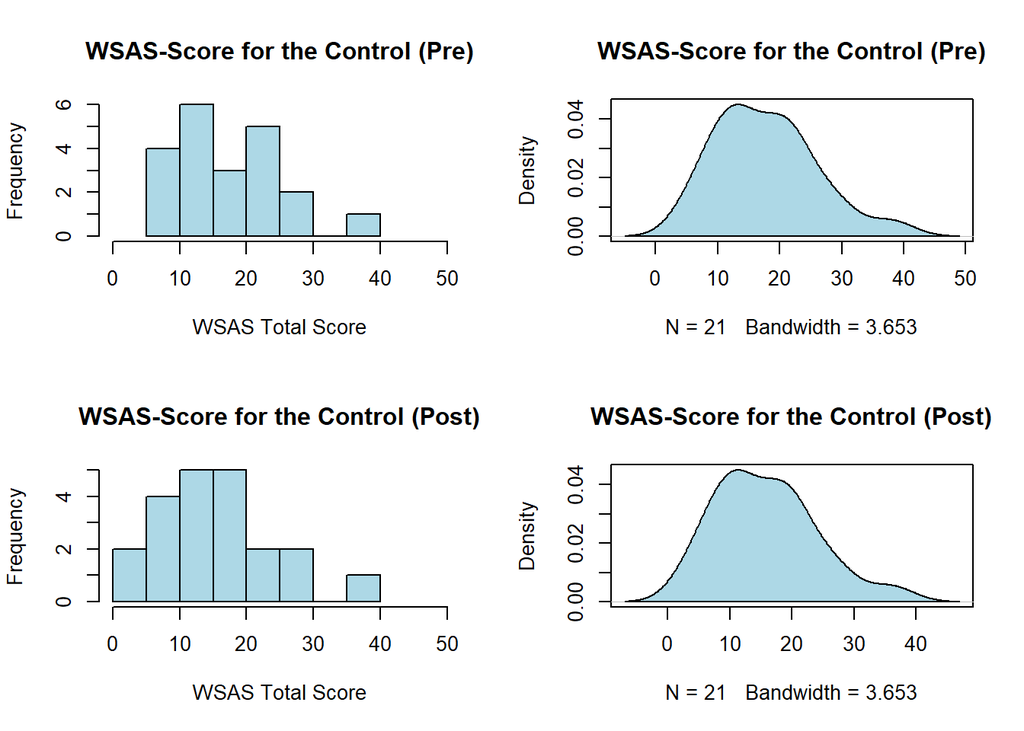

```r
# Control Group (Pre)
hist(data[data$treatment == "control" & data$time == "pre", 4],
     xlim  = c(0,50),
     main = "WSAS-Score for the Control (Pre)",
     xlab = "WSAS Total Score",
     col = "lightblue")


plot(density(data[data$treatment == "control" & data$time == "pre", 4],
             na.rm = T),
     main = "WSAS-Score for the Control (Pre)")
polygon(density(data[data$treatment == "control" & data$time == "pre", 4],
                na.rm = T),
        col = "lightblue")


# Control Group (Post)
hist(data[data$treatment == "control" & data$time == "post", 4],
     xlim  = c(0,50),
     main = "WSAS-Score for the Control (Post)",
     xlab = "WSAS Total Score",
     col = "lightblue")

plot(density(data[data$treatment == "control" & data$time == "post", 4],
             na.rm = T),
      main = "WSAS-Score for the Control (Post)")
polygon(density(data[data$treatment == "control" & data$time == "post", 4],
                na.rm = T),
        col = "lightblue")
```

### 4.3.5 MHQol-Score Distributions

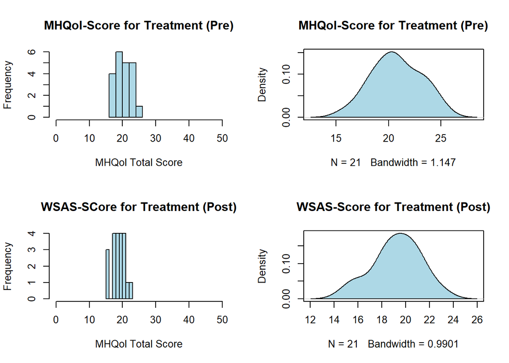

```r
###  MHQol- SCORE ###
par(mfrow=c(2,2))

# Treatment Group (Pre)
hist(data[data$treatment == "dCBT-I" & data$time == "pre", 5],
     xlim  = c(0,50),
     main = "MHQol-Score for Treatment (Pre)",
     xlab = "MHQol Total Score",
     col = "lightblue")

plot(density(data[data$treatment == "dCBT-I" & data$time == "pre", 5],
             na.rm = T),
      main = "MHQol-Score for Treatment (Pre)")
polygon(density(data[data$treatment == "dCBT-I" & data$time == "pre", 5],
                na.rm = T),
        col = "lightblue")


# Treatment Group (Post)
hist(data[data$treatment == "dCBT-I" & data$time == "post", 5],
     xlim  = c(0,50),
     main = "WSAS-SCore for Treatment (Post)",
     xlab = "MHQol Total Score",
     col = "lightblue")

plot(density(data[data$treatment == "dCBT-I" & data$time == "post", 5],
             na.rm = T),
      "WSAS-Score for Treatment (Post)")
polygon(density(data[data$treatment == "dCBT-I" & data$time == "post", 5],
                na.rm = T),
        col = "lightblue")
```

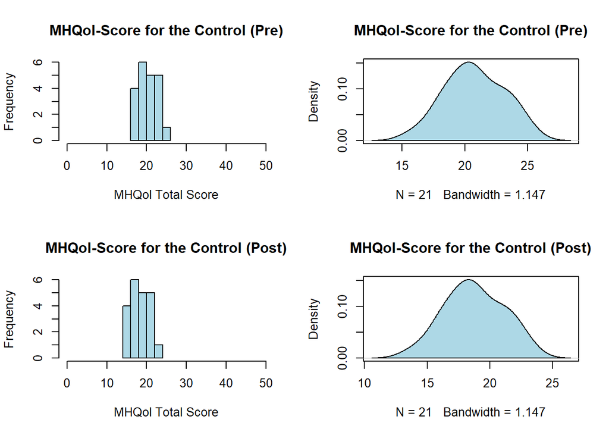

```r
# Control Group (Pre)
hist(data[data$treatment == "control" & data$time == "pre", 5],
     xlim  = c(0,50),
     main = "MHQol-Score for the Control (Pre)",
     xlab = "MHQol Total Score",
     col = "lightblue")

plot(density(data[data$treatment == "control" & data$time == "pre", 5],
             na.rm = T),
      main = "MHQol-Score for the Control (Pre)")
polygon(density(data[data$treatment == "control" & data$time == "pre", 5],
                na.rm = T),
        col = "lightblue")


# Control Group (Post)
hist(data[data$treatment == "control" & data$time == "post", 5],
     xlim  = c(0,50),
     main = "MHQol-Score for the Control (Post)",
     xlab = "MHQol Total Score",
     col = "lightblue")

plot(density(data[data$treatment == "control" & data$time == "post", 5],
             na.rm = T),
      main = "MHQol-Score for the Control (Post)")
polygon(density(data[data$treatment == "control" & data$time == "post", 5],
                na.rm = T),
        col = "lightblue")
```

### 4.3.6 MCTQ-SDWeek Distributions

Distributions for the average weekly sleep duration.

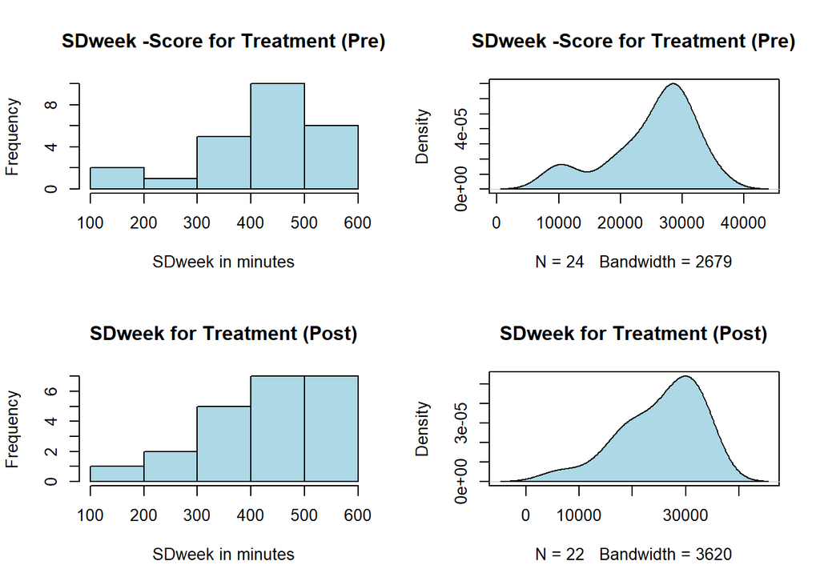

```r
###  MCTQ-SDweek TIME ###
par(mfrow=c(2,2))

# Treatment Group (Pre)
hist(as.numeric(data[data$treatment == "dCBT-I" & data$time == "pre", 6] / 60),
     main = "SDweek -Score for Treatment (Pre)",
     xlab = "SDweek in minutes",
     col = "lightblue")

plot(density(as.numeric(data[data$treatment == "dCBT-I"
                             & data$time == "pre", 6]),
             na.rm = T),
      main = "SDweek -Score for Treatment (Pre)")
polygon(density(as.numeric(data[data$treatment == "dCBT-I"
                                & data$time == "pre", 6]),
                na.rm = T),
        col = "lightblue")


# Treatment Group (Post)
hist(as.numeric(data[data$treatment == "dCBT-I" & data$time == "post", 6] / 60),
     main = "SDweek for Treatment (Post)",
     xlab = "SDweek in minutes",
     col = "lightblue")

plot(density(as.numeric(data[data$treatment == "dCBT-I"
                             & data$time == "post", 6]),
             na.rm = T),
      main = "SDweek for Treatment (Post)")
polygon(density(as.numeric(data[data$treatment == "dCBT-I"
                                & data$time == "post", 6]),
                na.rm = T),
        col = "lightblue")
```

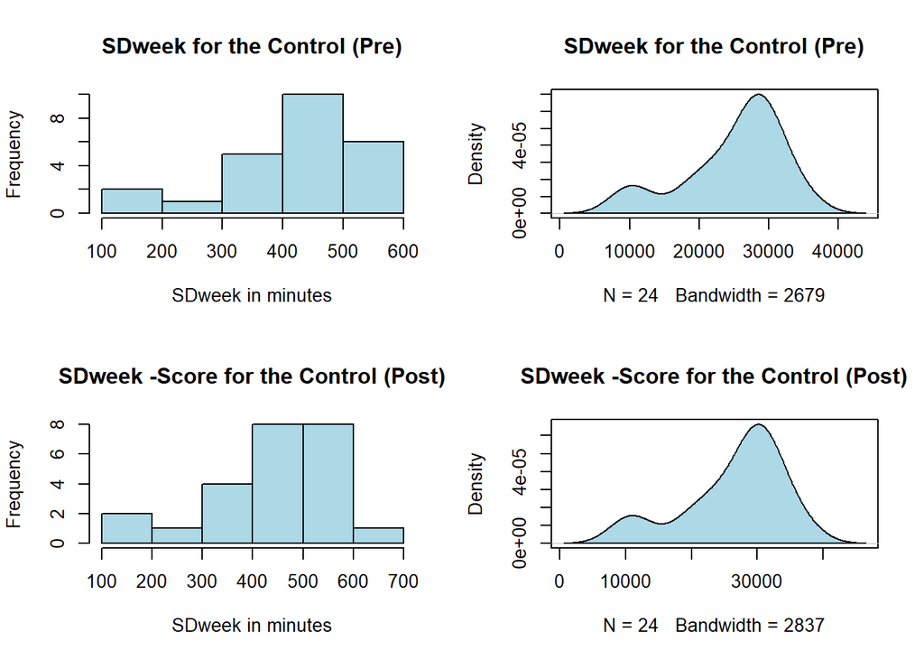

```r
# Control Group (Pre)
hist(as.numeric(data[data$treatment == "control" & data$time == "pre", 6] / 60),
     main = "SDweek for the Control (Pre)",
     xlab = "SDweek in minutes",
     col = "lightblue")

plot(density(as.numeric(data[data$treatment == "control"
                             & data$time == "pre", 6]),
             na.rm = T),
      main = "SDweek for the Control (Pre)")
polygon(density(as.numeric(data[data$treatment == "control"
                                & data$time == "pre", 6]),
                na.rm = T),
        col = "lightblue")


# Control Group (Post)
hist(as.numeric(data[data$treatment == "control"
                     & data$time == "post", 6] / 60),
     main = "SDweek -Score for the Control (Post)",
     xlab = "SDweek in minutes",
     col = "lightblue")

plot(density(as.numeric(data[data$treatment == "control"
                             & data$time == "post", 6]),
             na.rm = T),
      main = "SDweek -Score for the Control (Post)")
polygon(density(as.numeric(data[data$treatment == "control"
                                & data$time == "post", 6]),
                na.rm = T),
        col = "lightblue")
```

### 4.3.7 MCTQ-SLossWeek Distributions

Distributions for the average weekly sleep loss.

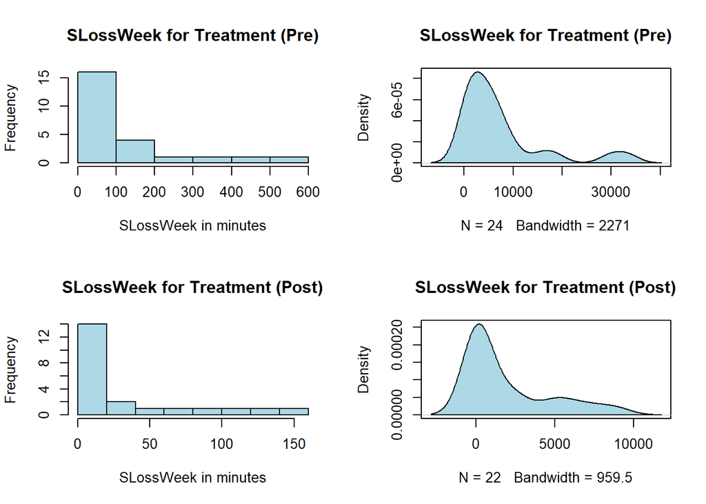

```r
###  MCTQ-MSF TIME ###
par(mfrow=c(2,2))

# Treatment Group (Pre)
hist(as.numeric(data[data$treatment == "dCBT-I" & data$time == "pre", 7] / 60),
     main = "SLossWeek for Treatment (Pre)",
     xlab = "SLossWeek in minutes",
     col = "lightblue")

plot(density(as.numeric(data[data$treatment == "dCBT-I"
                             & data$time == "pre", 7]),
             na.rm = T),
      main = "SLossWeek for Treatment (Pre)")
polygon(density(as.numeric(data[data$treatment == "dCBT-I"
                                & data$time == "pre", 7]),
                na.rm = T),
        col = "lightblue")


# Treatment Group (Post)
hist(as.numeric(data[data$treatment == "dCBT-I" & data$time == "post", 7] / 60),
     main = "SLossWeek for Treatment (Post)",
     xlab = "SLossWeek in minutes",
     col = "lightblue")

plot(density(as.numeric(data[data$treatment == "dCBT-I"
                             & data$time == "post", 7]),
             na.rm = T),
      main = "SLossWeek for Treatment (Post)")
polygon(density(as.numeric(data[data$treatment == "dCBT-I"
                                & data$time == "post", 7]),
                na.rm = T),
        col = "lightblue")
```

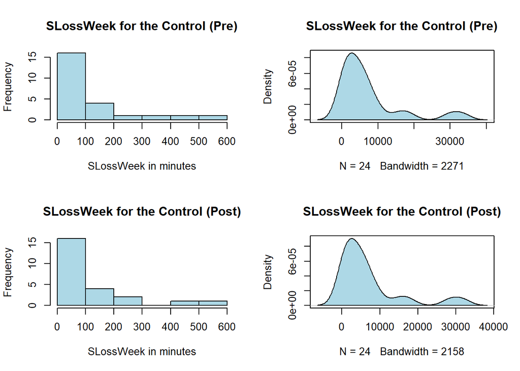

```r
# Control Group (Pre)
hist(as.numeric(data[data$treatment == "control" & data$time == "pre", 7] / 60),
     main = "SLossWeek for the Control (Pre)",
     xlab = "SLossWeek in minutes",
     col = "lightblue")

plot(density(as.numeric(data[data$treatment == "control"
                             & data$time == "pre", 7]),
             na.rm = T),
      main = "SLossWeek for the Control (Pre)")
polygon(density(as.numeric(data[data$treatment == "control"
                                & data$time == "pre", 7]),
                na.rm = T),
        col = "lightblue")


# Control Group (Post)
hist(as.numeric(data[data$treatment == "control"
                     & data$time == "post", 7]) / 60,
     main = "SLossWeek for the Control (Post)",
     xlab = "SLossWeek in minutes",
     col = "lightblue")

plot(density(as.numeric(data[data$treatment == "control"
                             & data$time == "post", 7]) ,
             na.rm = T),
      main = "SLossWeek for the Control (Post)")
polygon(density(as.numeric(data[data$treatment == "control"
                                & data$time == "post", 7]),
                na.rm = T),
        col = "lightblue")
```

### 4.3.8 MCTQ-SJL Distributions

Distributions for the absolute social jetlag.

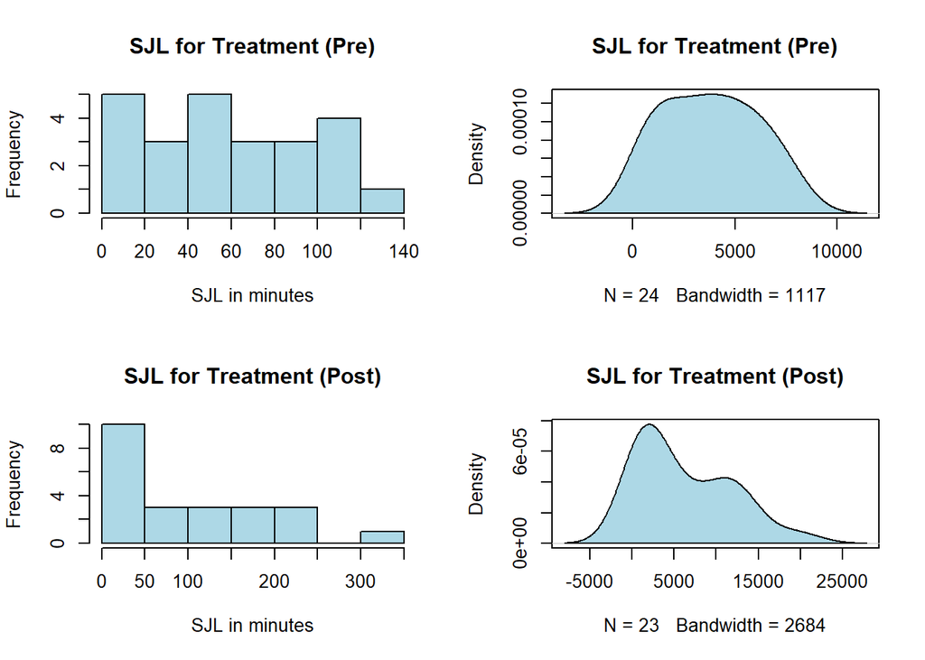

```r
###  MCTQ-SJL TIME ###
par(mfrow=c(2,2))

# Treatment Group (Pre)
hist(as.numeric(data[data$treatment == "dCBT-I" & data$time == "pre", 8]) / 60,
     main = "SJL for Treatment (Pre)",
     xlab = "SJL in minutes",
     col = "lightblue")

plot(density(as.numeric(data[data$treatment == "dCBT-I"
                             & data$time == "pre", 8]),
             na.rm = T),
      main = "SJL for Treatment (Pre)")
polygon(density(as.numeric(data[data$treatment == "dCBT-I"
                                & data$time == "pre", 8]),
                na.rm = T),
        col = "lightblue")


# Treatment Group (Post)
hist(as.numeric(data[data$treatment == "dCBT-I" & data$time == "post", 8]) / 60,
     main = "SJL for Treatment (Post)",
     xlab = "SJL in minutes",
     col = "lightblue")

plot(density(as.numeric(data[data$treatment == "dCBT-I"
                             & data$time == "post", 8]),
             na.rm = T),
      main = "SJL for Treatment (Post)")
polygon(density(as.numeric(data[data$treatment == "dCBT-I"
                                & data$time == "post", 8]),
                na.rm = T),
        col = "lightblue")
```

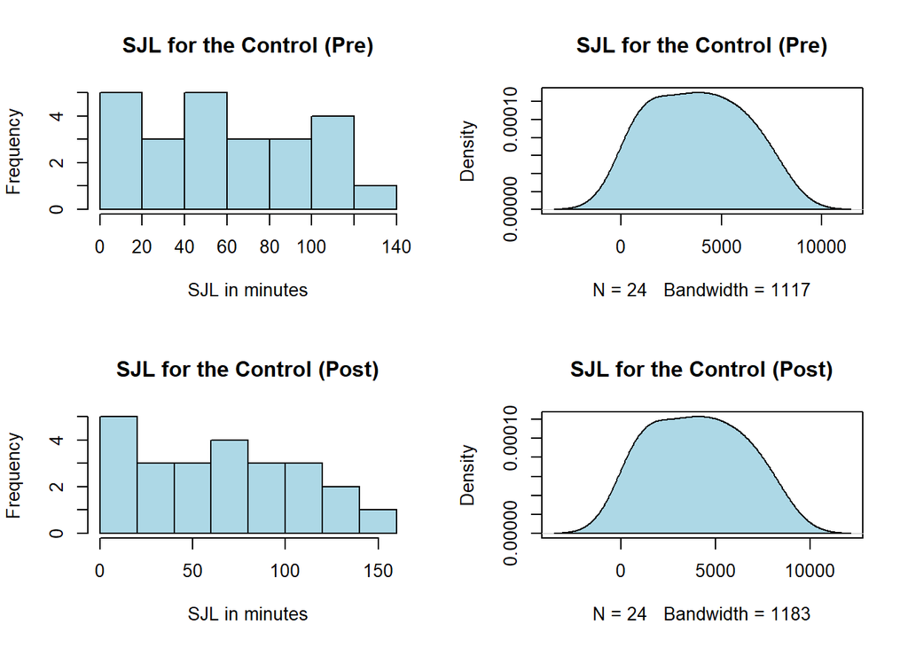

```r
# Control Group (Pre)
hist(as.numeric(data[data$treatment == "control" & data$time == "pre", 8]) / 60,
     main = "SJL for the Control (Pre)",
     xlab = "SJL in minutes",
     col = "lightblue")

plot(density(as.numeric(data[data$treatment == "control"
                             & data$time == "pre", 8]),
             na.rm = T),
      main = "SJL for the Control (Pre)")
polygon(density(as.numeric(data[data$treatment == "control"
                                & data$time == "pre", 8]),
                na.rm = T),
        col = "lightblue")


# Control Group (Post)
hist(as.numeric(data[data$treatment == "control"
                     & data$time == "post", 8]) / 60,
     main = "SJL for the Control (Post)",
     xlab = "SJL in minutes",
     col = "lightblue")

plot(density(as.numeric(data[data$treatment == "control"
                             & data$time == "post", 8]),
             na.rm = T),
      main = "SJL for the Control (Post)")
polygon(density(as.numeric(data[data$treatment == "control"
                                & data$time == "post", 8]),
                na.rm = T),
        col = "lightblue")
```

# 5. Results of the Analysis

## 5.1 LMM Results

In balanced case, ML and REML lead to same results but if the data is unbalanced, only REML can be used. Therefore, REML was used in all of the analysis as it is applicable in every case.

```r
# The full dataset was copied to test_data which was used in the analysis.
# This was done so that we would still have copy of the original data in case
# some changes are needed for the analysis.

test_data <- df_questionnaire_data
test_data$treatment <- as.numeric(test_data$treatment)

# Labeling treatment so that control = 0 and treatment = 1
test_data[test_data$treatment == "1", 11] <- 0
test_data[test_data$treatment == "2", 11] <- 1

# Labeling time so that pre = 0 and post = 1
test_data$time <- as.numeric(test_data$time)
test_data[test_data$time == 2, 10] <- 0
test_data[test_data$time == 1, 10] <- 1
```

```r
# Treatment and time were changed to categorical / factorised
test_data$treatment <- as.factor(test_data$treatment)
test_data$time <- as.factor(test_data$time)
```

### 5.1.1: Results for ISI-Score

```r
library(lme4)
library(lmerTest)
# Fitting the model
LMM_ISI <- lmer(ISI_total ~ treatment + time +  treatment:time +  ( 1|ID_reg),
               data = test_data,
               REML = T)

# Results of LMM
summary(LMM_ISI)
```

```
## Linear mixed model fit by REML. t-tests use Satterthwaite's method [
## lmerModLmerTest]
## Formula: ISI_total ~ treatment + time + treatment:time + (1 | ID_reg)
##    Data: test_data
##
## REML criterion at convergence: 515.3
##
## Scaled residuals:
##      Min       1Q   Median       3Q      Max
## -2.05877 -0.51928 -0.01279  0.52015  1.99873
##
## Random effects:
##  Groups   Name        Variance Std.Dev.
##  ID_reg   (Intercept) 8.242    2.871
##  Residual             5.481    2.341
## Number of obs: 100, groups:  ID_reg, 50
##
## Fixed effects:
##                    Estimate Std. Error         df t value Pr(>|t|)
## (Intercept)       1.612e+01  7.409e-01  7.055e+01  21.758  < 2e-16 ***
## treatment1        1.387e-14  1.048e+00  7.055e+01   0.000  1.00000
## time1            -2.000e+00  6.622e-01  4.800e+01  -3.020  0.00404 **
## treatment1:time1 -5.440e+00  9.364e-01  4.800e+01  -5.809  4.9e-07 ***
## ---
## Signif. codes:  0 '***' 0.001 '**' 0.01 '*' 0.05 '.' 0.1 ' ' 1
##
## Correlation of Fixed Effects:
##             (Intr) trtmn1 time1
## treatment1  -0.707
## time1       -0.447  0.316
## trtmnt1:tm1  0.316 -0.447 -0.707
```

```r
library(car)
```

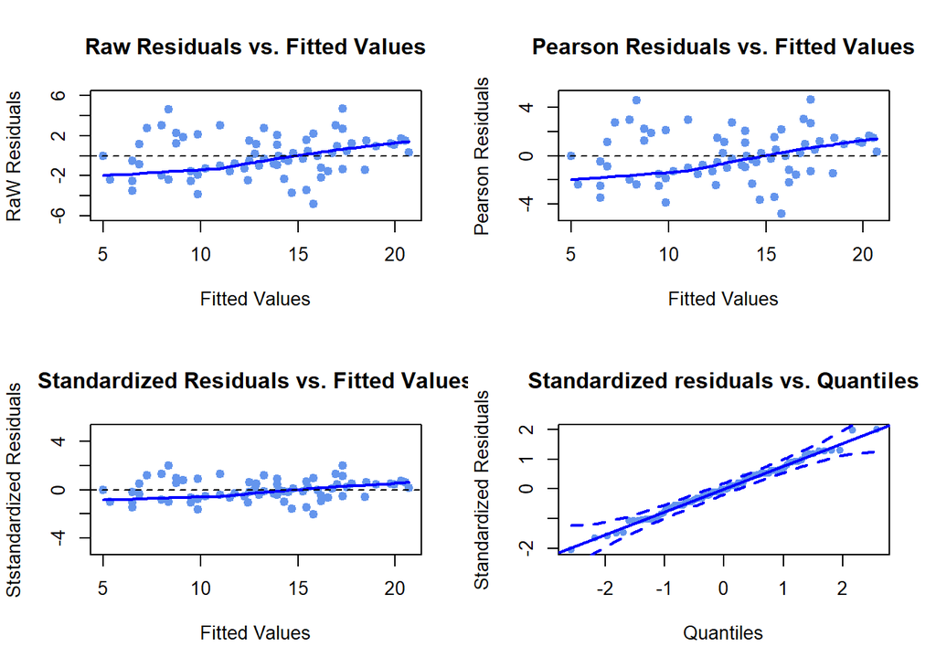

```r
par(mfrow=c(2,2))

### Equal Variance Assumption ###

## Plot residuals vs. fitted values:
## residuals should be approximately equally distributed around 0

## 1. Raw Residuals vs. Fitted values
plot(resid(LMM_ISI, type = "response") ~ fitted(LMM_ISI),
    main = "Raw Residuals vs. Fitted Values",
     ylab = "RaW Residuals",
     ylim = c(-6, 6),
     xlab = "Fitted Values",
     pch = 19,
     col = "cornflowerblue")
lines(lowess(fitted(LMM_ISI), resid(LMM_ISI, type = "response")),
      col = "blue", lwd = 2)
abline(h = 0, col = "black", lty = 2)

## 2. Pearson Residuals vs. Fitted values
plot(resid(LMM_ISI, type = "pearson") ~ fitted(LMM_ISI),
    main = "Pearson Residuals vs. Fitted Values",
     ylab = "Pearson Residuals",
     ylim = c(-5, 5),
     xlab = "Fitted Values",
     pch = 19,
     col = "cornflowerblue")
lines(lowess(fitted(LMM_ISI), resid(LMM_ISI, type = "pearson")),
      col = "blue", lwd = 2)
abline(h = 0, col = "black", lty = 2)

## 3. Standardized Residuals vs. Fitted values
plot(resid(LMM_ISI, scaled = T) ~ fitted(LMM_ISI),
    main = "Standardized Residuals vs. Fitted Values",
     ylab = "Ststandardized Residuals",
     ylim = c(-5, 5),
     xlab = "Fitted Values",
     pch = 19,
     col = "cornflowerblue")
lines(lowess(fitted(LMM_ISI), resid(LMM_ISI, scaled = T)),
      col = "blue", lwd = 2)
abline(h = 0, col = "black", lty = 2)



### Normally Distributed Residuals Assumption ###

## 1. QQ-plot of the standardized residuals
qqPlot(resid(LMM_ISI, scaled = T),
       main = "Standardized residuals vs. Quantiles",
       ylab = "Standardized Residuals",
       xlab = "Quantiles",
       pch = 19,
       col = "cornflowerblue",
       grid = F,
       id = F,
       envelope = list(style = "lines"))
```

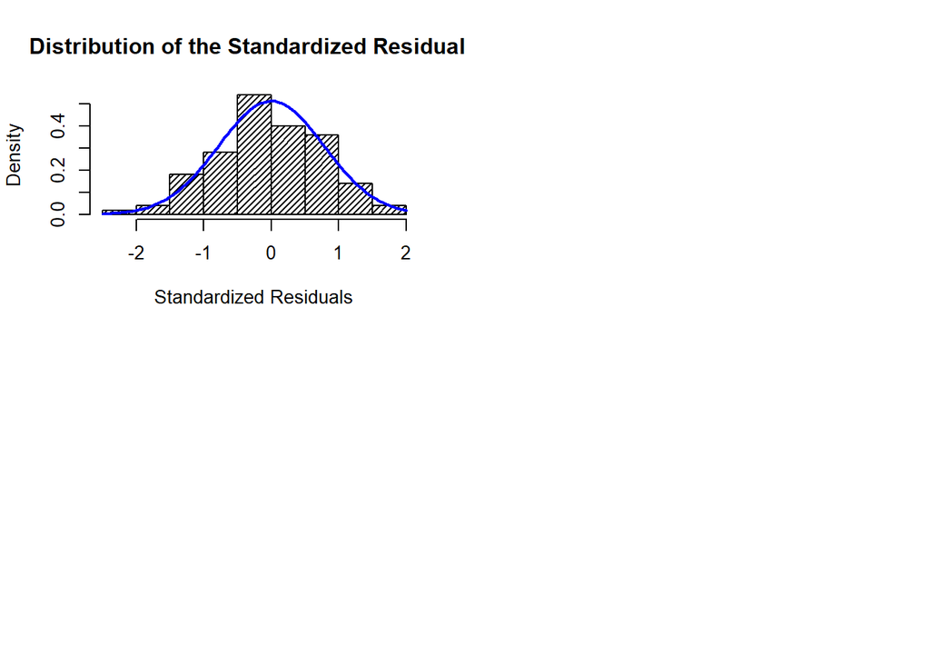

```r
## 2. Histogram of the standardized residuals
hist(resid(LMM_ISI, scaled = T),
     density = 30, col = "black",
     main = "Distribution of the Standardized Residuals",
     xlab = "Standardized Residuals",
     prob = T)
curve(dnorm(x, mean = mean(resid(LMM_ISI, scaled = T)),
            sd = sd(resid(LMM_ISI, scaled = T))),
      col = "blue", lwd = 2, add = T, yaxt="n")
```

We can see that the residuals, especially when standardized, have a normal distributions and are approximately equally distributed around 0.

### 5.1.2: Results for PHQ-score

```r
library(lme4)
library(lmerTest)


# Fitting the model
LMM_PHQ <- lmer(PHQ_total ~ treatment + time +  treatment:time +  ( 1|ID_reg),
               data = test_data,
               REML = T)

# Results of LMM
summary(LMM_PHQ)
```

```
## Linear mixed model fit by REML. t-tests use Satterthwaite's method [
## lmerModLmerTest]
## Formula: PHQ_total ~ treatment + time + treatment:time + (1 | ID_reg)
##    Data: test_data
##
## REML criterion at convergence: 431.2
##
## Scaled residuals:
##      Min       1Q   Median       3Q      Max
## -1.88370 -0.56323  0.04693  0.51681  1.95685
##
## Random effects:
##  Groups   Name        Variance Std.Dev.
##  ID_reg   (Intercept) 5.117    2.262
##  Residual             7.040    2.653
## Number of obs: 84, groups:  ID_reg, 42
##
## Fixed effects:
##                    Estimate Std. Error         df t value Pr(>|t|)
## (Intercept)       1.067e+01  7.609e-01  6.796e+01  14.019  < 2e-16 ***
## treatment1       -1.913e-14  1.076e+00  6.796e+01   0.000 1.000000
## time1            -1.000e+00  8.189e-01  4.000e+01  -1.221 0.229152
## treatment1:time1 -4.810e+00  1.158e+00  4.000e+01  -4.153 0.000167 ***
## ---
## Signif. codes:  0 '***' 0.001 '**' 0.01 '*' 0.05 '.' 0.1 ' ' 1
##
## Correlation of Fixed Effects:
##             (Intr) trtmn1 time1
## treatment1  -0.707
## time1       -0.538  0.381
## trtmnt1:tm1  0.381 -0.538 -0.707
```

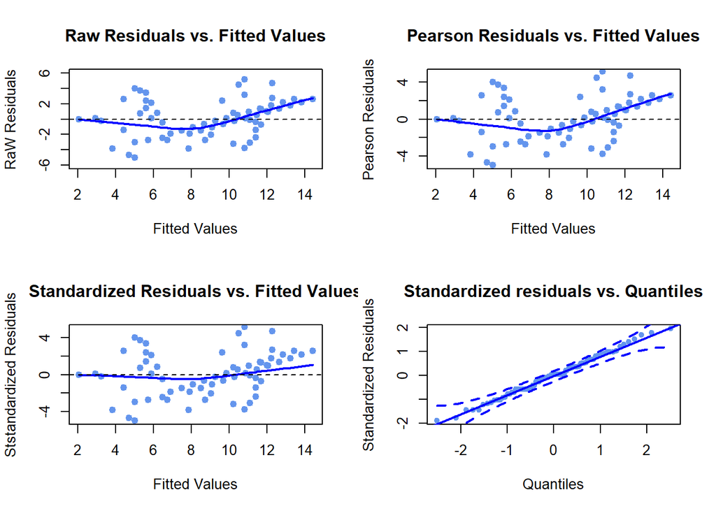

```r
library(car)
par(mfrow=c(2,2))

### Equal Variance Assumption ###

## 1. Raw Residuals vs. Fitted values
plot(resid(LMM_PHQ, type = "response") ~ fitted(LMM_PHQ),
    main = "Raw Residuals vs. Fitted Values",
     ylab = "RaW Residuals",
     ylim = c(-6, 6),
     xlab = "Fitted Values",
     pch = 19,
     col = "cornflowerblue")
lines(lowess(fitted(LMM_PHQ), resid(LMM_PHQ, type = "response")),
      col = "blue", lwd = 2)
abline(h = 0, col = "black", lty = 2)

## 2. Pearson Residuals vs. Fitted values
plot(resid(LMM_PHQ, type = "pearson") ~ fitted(LMM_PHQ),
    main = "Pearson Residuals vs. Fitted Values",
     ylab = "Pearson Residuals",
     ylim = c(-5, 5),
     xlab = "Fitted Values",
     pch = 19,
     col = "cornflowerblue")
lines(lowess(fitted(LMM_PHQ), resid(LMM_PHQ, type = "pearson")),
      col = "blue", lwd = 2)
abline(h = 0, col = "black", lty = 2)

## 3. Standardized Residuals vs. Fitted values
plot(resid(LMM_PHQ) ~ fitted(LMM_PHQ),
    main = "Standardized Residuals vs. Fitted Values",
     ylab = "Ststandardized Residuals",
     ylim = c(-5, 5),
     xlab = "Fitted Values",
     pch = 19,
     col = "cornflowerblue")
lines(lowess(fitted(LMM_PHQ), resid(LMM_PHQ, scaled = T)),
      col = "blue", lwd = 2)
abline(h = 0, col = "black", lty = 2)


### Normally Distributed Residuals Assumption ###

## 1. QQ-plot of the standardized residuals
qqPlot(resid(LMM_PHQ, scaled = T),
       main = "Standardized residuals vs. Quantiles",
       ylab = "Standardized Residuals",
       xlab = "Quantiles",
       pch = 19,
       col = "cornflowerblue",
       grid = F,
       id = F,
       envelope = list(style = "lines"))
```

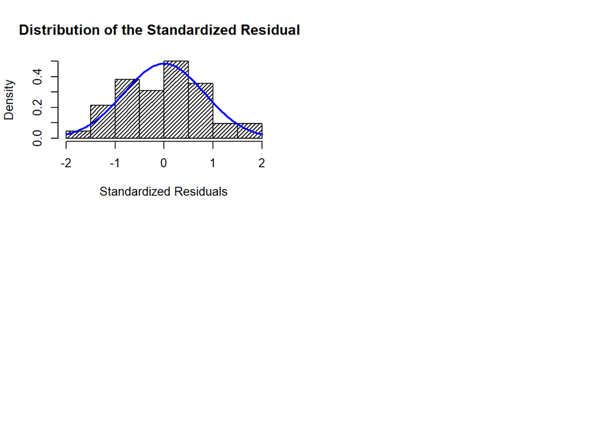

```r
## 2. Histogram of the standardized residuals
hist(resid(LMM_PHQ, scaled = T),
     density = 30, col = "black",
     main = "Distribution of the Standardized Residuals",
     xlab = "Standardized Residuals",
     prob = T)
curve(dnorm(x, mean = mean(resid(LMM_PHQ, scaled = T)),
            sd = sd(residuals(LMM_PHQ, scaled = T))),
      col = "blue", lwd = 2, add = T, yaxt="n")
```

### 5.1.3: Results of GAD-Scores

```r
library(lme4)
library(lmerTest)

# Fitting the model
LMM_GAD <- lmer(GAD_total ~ treatment + time +  treatment:time +  ( 1|ID_reg),
               data = test_data,
               REML = T)


# Results of LMM
summary(LMM_GAD)
```

```
## Linear mixed model fit by REML. t-tests use Satterthwaite's method [
## lmerModLmerTest]
## Formula: GAD_total ~ treatment + time + treatment:time + (1 | ID_reg)
##    Data: test_data
##
## REML criterion at convergence: 456.7
##
## Scaled residuals:
##      Min       1Q   Median       3Q      Max
## -2.03893 -0.46607 -0.00873  0.38512  1.91203
##
## Random effects:
##  Groups   Name        Variance Std.Dev.
##  ID_reg   (Intercept) 14.20    3.768
##  Residual              6.57    2.563
## Number of obs: 84, groups:  ID_reg, 42
##
## Fixed effects:
##                    Estimate Std. Error         df t value Pr(>|t|)
## (Intercept)       8.571e+00  9.945e-01  5.452e+01   8.619 9.29e-12 ***
## treatment1        4.024e-15  1.406e+00  5.452e+01   0.000   1.0000
## time1            -9.048e-01  7.910e-01  4.000e+01  -1.144   0.2595
## treatment1:time1 -3.000e+00  1.119e+00  4.000e+01  -2.682   0.0106 *
## ---
## Signif. codes:  0 '***' 0.001 '**' 0.01 '*' 0.05 '.' 0.1 ' ' 1
##
## Correlation of Fixed Effects:
##             (Intr) trtmn1 time1
## treatment1  -0.707
## time1       -0.398  0.281
## trtmnt1:tm1  0.281 -0.398 -0.707
```

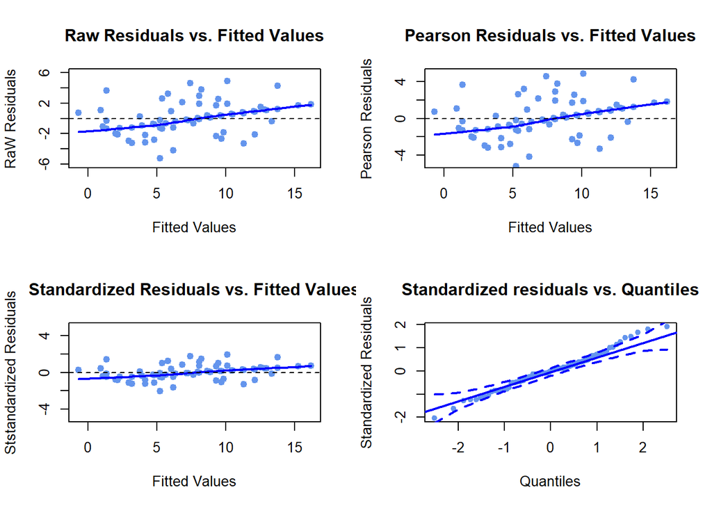

```r
library(car)
par(mfrow=c(2,2))

### Equal Variance Assumption ###

## 1. Raw Residuals vs. Fitted values
plot(resid(LMM_GAD, type = "response") ~ fitted(LMM_GAD),
    main = "Raw Residuals vs. Fitted Values",
     ylab = "RaW Residuals",
     ylim = c(-6, 6),
     xlab = "Fitted Values",
     pch = 19,
     col = "cornflowerblue")
lines(lowess(fitted(LMM_GAD), resid(LMM_GAD, type = "response")),
      col = "blue", lwd = 2)
abline(h = 0, col = "black", lty = 2)

## 2. Pearson Residuals vs. Fitted values
plot(resid(LMM_GAD, type = "pearson") ~ fitted(LMM_GAD),
    main = "Pearson Residuals vs. Fitted Values",
     ylab = "Pearson Residuals",
     ylim = c(-5, 5),
     xlab = "Fitted Values",
     pch = 19,
     col = "cornflowerblue")
lines(lowess(fitted(LMM_GAD), resid(LMM_GAD, type = "pearson")),
      col = "blue", lwd = 2)
abline(h = 0, col = "black", lty = 2)

## 3. Standardized Residuals vs. Fitted values
plot(resid(LMM_GAD, scaled = T) ~ fitted(LMM_GAD),
     main = "Standardized Residuals vs. Fitted Values",
     ylab = "Ststandardized Residuals",
     ylim = c(-5, 5),
     xlab = "Fitted Values",
     pch = 19,
     col = "cornflowerblue")
lines(lowess(fitted(LMM_GAD), resid(LMM_GAD, scaled = T)),
      col = "blue", lwd = 2)
abline(h = 0, col = "black", lty = 2)


### Normally Distributed Residuals Assumption ###

## 1. QQ-plot of the standardized residuals
qqPlot(resid(LMM_GAD, scaled = T),
       main = "Standardized residuals vs. Quantiles",
       ylab = "Standardized Residuals",
       xlab = "Quantiles",
       pch = 19,
       col = "cornflowerblue",
       grid = F,
       id = F,
       envelope = list(style = "lines"))
```

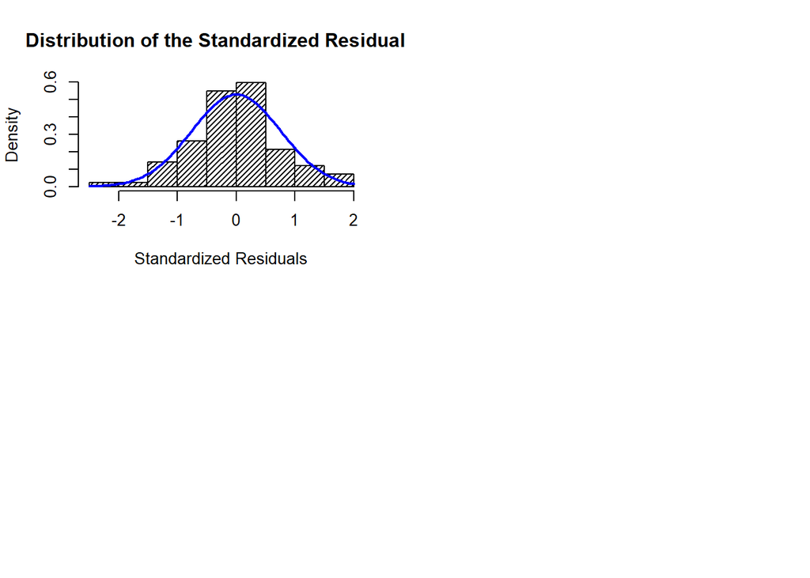

```r
## 2. Histogram of the standardized residuals
hist(resid(LMM_GAD, scaled = T),
     density = 30, col = "black",
     main = "Distribution of the Standardized Residuals",
     xlab = "Standardized Residuals",
     prob = T)
curve(dnorm(x, mean = mean(resid(LMM_GAD, scaled = T)),
            sd = sd(resid(LMM_GAD, scaled = T))),
      col = "blue", lwd = 2, add = T, yaxt="n")
```

No violation of the assumptions.